# econ430-co2-agriculture

### Distribution Analysis

- **Yield_per_hectare:** Normal, Gamma, and Lognormal.
- **Fertilizer_consp:** Gamma, Lognormal, Exponential.
- **AnnualRainfall:** Gamma, Lognormal, Normal.
- **Gross_irrigated_area:** Gamma, Normal, Lognormal.
- **Cropping_intensity:** Lognormal, Gamma, Exponential.
- **Agri_credit:** Exponential, Gamma, Lognormal.
- **MaxTemp:** Lognormal, Gamma, Exponential.
- **Gross_sown_area:** Gamma, Normal, Lognormal.
- **CO2_emission:** Uniform, Gamma, Lognormal.
- **Irrigation_Ratio:** Gamma, Normal, Lognormal.

```python
#fitter graphs
!pip install fitter
from fitter import Fitter
```

[output not shown]

|  | sumsquare_error | aic | bic | kl_div | ks_statistic | ks_pvalue |
| --- | --- | --- | --- | --- | --- | --- |
| lognorm | 4.850671e-07 | 1875.084960 | 1888.374118 | inf | 0.045363 | 1.511552e-01 |
| gamma | 5.128528e-07 | 1874.576725 | 1887.865884 | inf | 0.041636 | 2.263426e-01 |
| norm | 1.195144e-06 | 1943.715091 | 1952.574530 | inf | 0.114260 | 1.656305e-07 |

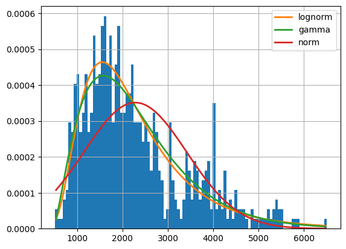

```python
plt.figure()
data_fit = Fitter(agri_p['Yield_per_hectare'], distributions=[ 'norm', 'gamma', 'lognorm'])
data_fit.fit()
plt.title("Fitting for 'Yield_per_hectare'")
data_fit.summary()
```

|  | sumsquare_error | aic | bic | kl_div | ks_statistic | ks_pvalue |
| --- | --- | --- | --- | --- | --- | --- |
| lognorm | 0.000153 | 1445.461780 | 1458.750938 | inf | 0.044549 | 1.655969e-01 |
| gamma | 0.000159 | 1446.559793 | 1459.848951 | inf | 0.042434 | 2.082159e-01 |
| expon | 0.000251 | 1402.805456 | 1411.664895 | inf | 0.135759 | 1.989525e-10 |
| norm | 0.000273 | 1675.383491 | 1684.242930 | inf | 0.127315 | 3.209416e-09 |

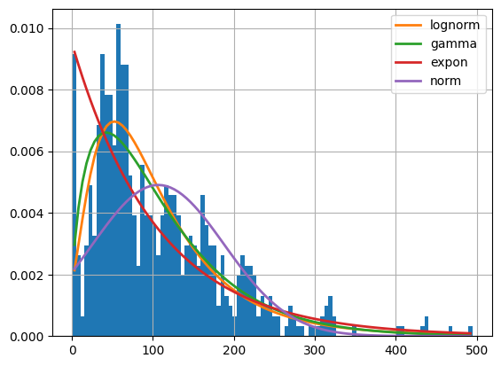

```python
plt.figure()
data_fit = Fitter(agri_p['Fertilizer_consp'], distributions=[ 'norm','lognorm', 'gamma', 'expon'])
data_fit.fit()
plt.title("Fitting for Fertilizer_consp")
data_fit.summary()
```

|  | sumsquare_error | aic | bic | kl_div | ks_statistic | ks_pvalue |
| --- | --- | --- | --- | --- | --- | --- |
| lognorm | 0.000002 | 1738.132347 | 1751.421506 | inf | 0.051163 | 7.519892e-02 |
| gamma | 0.000002 | 1733.951119 | 1747.240277 | inf | 0.060182 | 2.148925e-02 |
| norm | 0.000004 | 1758.691954 | 1767.551393 | inf | 0.126948 | 3.606326e-09 |

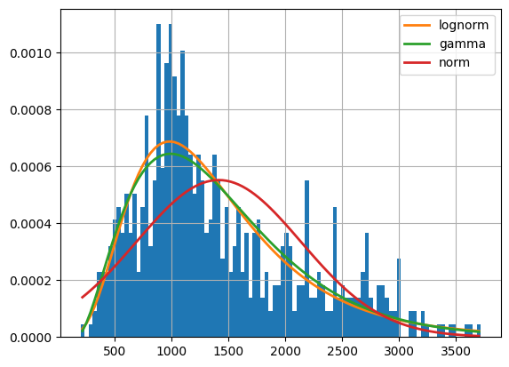

```python
plt.figure()
data_fit = Fitter(agri_p['AnnualRainfall'], distributions=[ 'norm', 'gamma', 'lognorm'])
data_fit.fit()
plt.title("Fitting for 'AnnualRainfall'")
data_fit.summary()
```

|  | sumsquare_error | aic | bic | kl_div | ks_statistic | ks_pvalue |
| --- | --- | --- | --- | --- | --- | --- |
| lognorm | 8.433640e-07 | 2182.227561 | 2195.516719 | inf | 0.244038 | 5.380230e-33 |
| gamma | 9.845499e-07 | 2159.040490 | 2172.329648 | inf | 0.196136 | 2.257452e-21 |
| norm | 1.708929e-06 | 2432.335819 | 2441.195258 | inf | 0.183684 | 8.821369e-19 |

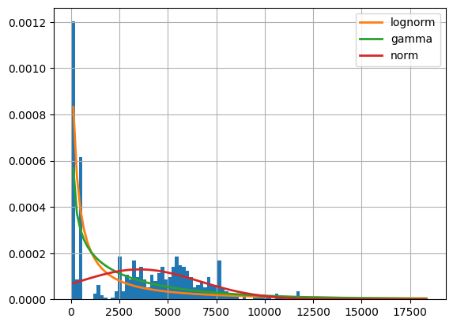

```python
plt.figure()
data_fit = Fitter(agri_p['Gross_irrigated_area'], distributions=[ 'norm', 'gamma', 'lognorm'])
data_fit.fit()
plt.title("Fitting for Gross_irrigated_area")
data_fit.summary()
```

|  | sumsquare_error | aic | bic | kl_div | ks_statistic | ks_pvalue |
| --- | --- | --- | --- | --- | --- | --- |
| lognorm | 0.001176 | 1239.459422 | 1252.748580 | inf | 0.050181 | 8.513997e-02 |
| gamma | 0.001262 | 1232.864438 | 1246.153596 | inf | 0.060578 | 2.024525e-02 |
| norm | 0.001933 | 1332.658547 | 1341.517986 | inf | 0.129509 | 1.585718e-09 |

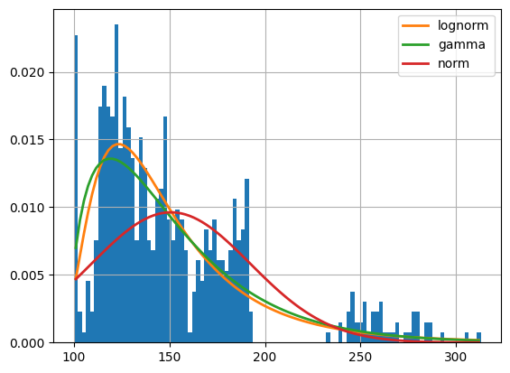

```python
plt.figure()
data_fit = Fitter(agri_p['Cropping_intensity'], distributions=[ 'norm', 'gamma', 'lognorm'])
data_fit.fit()
plt.title("Fitting for Cropping_intensity")
data_fit.summary()
```

|  | sumsquare_error | aic | bic | kl_div | ks_statistic | ks_pvalue |
| --- | --- | --- | --- | --- | --- | --- |
| lognorm | 0.000036 | 1883.923114 | 1897.212272 | inf | 0.058987 | 2.566795e-02 |
| gamma | 0.000156 | 1792.920743 | 1806.209902 | inf | 0.120154 | 2.944647e-08 |
| expon | 0.000279 | 2150.207503 | 2159.066942 | inf | 0.346382 | 5.834969e-67 |
| norm | 0.000440 | 2303.534798 | 2312.394237 | inf | 0.288493 | 3.496186e-46 |

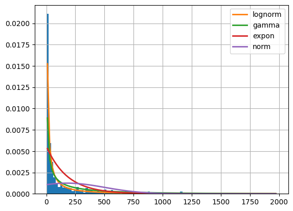

```python
plt.figure()
data_fit = Fitter(agri_p['Agri_credit'], distributions=[ 'norm', 'gamma', 'lognorm', 'expon'])
data_fit.fit()
plt.title("Fitting for Agri_credit")
data_fit.summary()
```

|  | sumsquare_error | aic | bic | kl_div | ks_statistic | ks_pvalue |
| --- | --- | --- | --- | --- | --- | --- |
| lognorm | 0.399690 | 911.119369 | 924.408527 | inf | 0.322075 | 9.972317e-58 |
| gamma | 0.413885 | 905.734704 | 919.023862 | inf | 0.343848 | 5.801725e-66 |
| expon | 0.532788 | 776.585071 | 785.444510 | inf | 0.475833 | 1.788004e-129 |

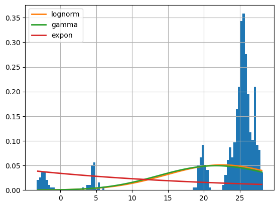

```python
plt.figure()
data_fit = Fitter(agri_p['MaxTemp'], distributions=[ 'gamma', 'lognorm', 'expon'])
data_fit.fit()
plt.title("Fitting for MaxTemp")
data_fit.summary()
```

|  | sumsquare_error | aic | bic | kl_div | ks_statistic | ks_pvalue |
| --- | --- | --- | --- | --- | --- | --- |
| gamma | 1.716387e-07 | 2216.481976 | 2229.771135 | inf | 0.112956 | 2.399013e-07 |
| lognorm | 2.363993e-07 | 2242.669591 | 2255.958750 | inf | 0.137213 | 1.210186e-10 |
| norm | 2.764597e-07 | 2234.610340 | 2243.469778 | inf | 0.136766 | 1.410735e-10 |

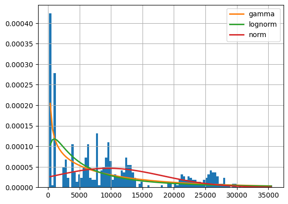

```python
plt.figure()
data_fit = Fitter(agri_p['Gross_sown_area'], distributions=[ 'norm', 'gamma', 'lognorm'])
data_fit.fit()
plt.title("Fitting for Gross_sown_area")
data_fit.summary()
```

|  | sumsquare_error | aic | bic | kl_div | ks_statistic | ks_pvalue |
| --- | --- | --- | --- | --- | --- | --- |
| uniform | 231.997599 | 31.629342 | 40.488781 | inf | 0.226898 | 1.561768e-28 |
| lognorm | 232.420326 | 99.647909 | 112.937068 | inf | 0.127211 | 3.317011e-09 |
| norm | 249.999002 | 75.165864 | 84.025303 | inf | 0.180528 | 3.754166e-18 |
| gamma | 295.882153 | 165.934185 | 179.223343 | inf | 0.282308 | 3.309746e-44 |

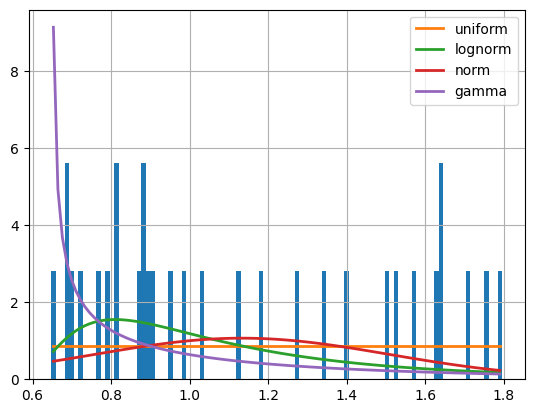

```python
plt.figure()
data_fit = Fitter(agri_p['CO2_emission'], distributions=['uniform', 'norm', 'gamma', 'lognorm'])
data_fit.fit()
plt.title("Fitting for CO2_emission")
data_fit.summary()
```

|  | sumsquare_error | aic | bic | kl_div | ks_statistic | ks_pvalue |
| --- | --- | --- | --- | --- | --- | --- |
| lognorm | 0.004743 | 998.744968 | 1012.034127 | inf | 0.045003 | 1.574022e-01 |
| gamma | 0.005025 | 989.831399 | 1003.120558 | inf | 0.054040 | 5.155162e-02 |
| norm | 0.007216 | 995.408440 | 1004.267879 | inf | 0.119294 | 3.809348e-08 |

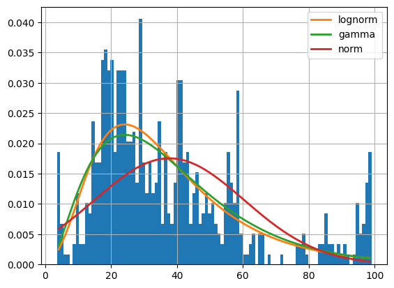

```python
plt.figure()
data_fit = Fitter(agri_p['Irrigation_Ratio'], distributions=[ 'norm', 'gamma', 'lognorm'])
data_fit.fit()
plt.title("Fitting for Irrigation_Ratio")
data_fit.summary()
```

### Distribution Fitting Analysis

- **Yield_per_hectare:** Lognormal fits best.
- **Fertilizer_consp:** Lognormal.
- **AnnualRainfall:** Lognormal.
- **Gross_irrigated_area:** Lognormal.
- **Cropping_intensity:** Lognormal.
- **Agri_credit:** Lognormal.
- **MaxTemp:** Lognormal.
- **Gross_sown_area:** Gamma.
- **CO2_emission:** Uniform.
- **Irrigation_Ratio:** Lognormal.

We will apply the appropriate transformations based on these findings.

## Model Fitting

We now proceed to fit Pooled, Fixed Effects, and Random Effects Models to our panel data.

```python
#transformations
agri_p['lyield'] = np.log(agri_p['Yield_per_hectare'])
agri_p['lfertilizer'] = np.log(agri_p['Fertilizer_consp'])
agri_p['lrain'] = np.log(agri_p['AnnualRainfall'])
agri_p['lirrigated'] = np.log(agri_p['Gross_irrigated_area'])
agri_p['lcrop'] = np.log(agri_p['Cropping_intensity'])
agri_p['lcred'] = np.log(agri_p['Agri_credit'])
agri_p['lsown'] = np.log(agri_p['Gross_sown_area'])
agri_p['lirr_ratio'] = np.log(agri_p['Irrigation_Ratio'])
agri_p['lCo2'] = np.log(agri_p['CO2_emission'])
agri_p['MaxTemp'] = (agri_p['MaxTemp'] *(9/5)) + 32
agri_p['ltemp'] = np.log(agri_p['MaxTemp'])
```

```python
# Specify Pooled OLS
nls_pooled_model = PooledOLS.from_formula(
    'lyield~ 1 + lCo2 + lfertilizer + lrain + lirrigated + lcrop + lcred + lsown + lirr_ratio + ltemp ',
    data=agri_p)

# Estimating basic model
nls_pooled1 = nls_pooled_model.fit()
print(nls_pooled1.summary)
```

```
                          PooledOLS Estimation Summary
================================================================================
Dep. Variable:                 lyield   R-squared:                        0.5837
Estimator:                  PooledOLS   R-squared (Between):              0.5349
No. Observations:                 620   R-squared (Within):               0.6821
Date:                Sat, Jan 18 2025   R-squared (Overall):              0.5837
Time:                        19:07:24   Log-likelihood                   -163.45
Cov. Estimator:            Unadjusted
                                        F-statistic:                      95.029
Entities:                          20   P-value                           0.0000
Avg Obs:                       31.000   Distribution:                   F(9,610)
Min Obs:                       31.000
Max Obs:                       31.000   F-statistic (robust):          1.648e+06
                                        P-value                           0.0000
Time periods:                      31   Distribution:                   F(9,610)
Avg Obs:                       20.000
Min Obs:                       20.000
Max Obs:                       20.000

                              Parameter Estimates
===============================================================================
             Parameter  Std. Err.     T-stat    P-value    Lower CI    Upper CI
-------------------------------------------------------------------------------
Intercept   -3.746e+08  1.733e+05    -2161.9     0.0000   -3.75e+08  -3.743e+08
lCo2            0.2903     0.0484     5.9921     0.0000      0.1952      0.3854
lfertilizer     0.2378     0.0177     13.457     0.0000      0.2031      0.2725
lrain           0.1633     0.0379     4.3051     0.0000      0.0888      0.2378
lirrigated  -8.135e+07  3.763e+04    -2161.9     0.0000  -8.143e+07  -8.128e+07
lcrop           0.9131     0.0630     14.501     0.0000      0.7895      1.0368
lcred          -0.0081     0.0060    -1.3575     0.1751     -0.0199      0.0036
lsown        8.135e+07  3.763e+04     2161.9     0.0000   8.128e+07   8.143e+07
lirr_ratio   8.135e+07  3.763e+04     2161.9     0.0000   8.128e+07   8.143e+07
ltemp           0.4655     0.0628     7.4140     0.0000      0.3422      0.5888
===============================================================================
```

### Key Insights

- **lCo2, lfertilizer, lrain, lcrop,** and **ltemp** have statistically significant, positive effects on yield.
- **Fertilizer** and **crop area** are particularly strong drivers of yield.

```python
# Estimate the Pooled OLS w/ cluster-robust standard errors
nls_pooled2 = nls_pooled_model.fit(cov_type='clustered', cluster_entity=True)
## Note: `cluster_entity=True` uses indices as clusters, which is what we want

print(nls_pooled2.summary)
```

```
                          PooledOLS Estimation Summary
================================================================================
Dep. Variable:                 lyield   R-squared:                        0.5837
Estimator:                  PooledOLS   R-squared (Between):              0.5349
No. Observations:                 620   R-squared (Within):               0.6821
Date:                Sat, Jan 18 2025   R-squared (Overall):              0.5837
Time:                        19:07:27   Log-likelihood                   -163.45
Cov. Estimator:             Clustered
                                        F-statistic:                      95.029
Entities:                          20   P-value                           0.0000
Avg Obs:                       31.000   Distribution:                   F(9,610)
Min Obs:                       31.000
Max Obs:                       31.000   F-statistic (robust):            -4018.5
                                        P-value                           1.0000
Time periods:                      31   Distribution:                   F(9,610)
Avg Obs:                       20.000
Min Obs:                       20.000
Max Obs:                       20.000

                              Parameter Estimates
===============================================================================
             Parameter  Std. Err.     T-stat    P-value    Lower CI    Upper CI
-------------------------------------------------------------------------------
Intercept   -3.746e+08  5.014e+05    -747.17     0.0000  -3.756e+08  -3.737e+08
lCo2            0.2903     0.0902     3.2201     0.0013      0.1133      0.4673
lfertilizer     0.2378     0.0480     4.9519     0.0000      0.1435      0.3321
lrain           0.1633     0.1047     1.5592     0.1195     -0.0424      0.3690
lirrigated  -8.135e+07  1.004e+05    -809.95     0.0000  -8.155e+07  -8.116e+07
lcrop           0.9131     0.2194     4.1614     0.0000      0.4822      1.3440
lcred          -0.0081     0.0100    -0.8173     0.4141     -0.0277      0.0114
lsown        8.135e+07  1.158e+05     702.50     0.0000   8.113e+07   8.158e+07
lirr_ratio   8.135e+07  1.153e+05     705.30     0.0000   8.113e+07   8.158e+07
ltemp           0.4655     0.1457     3.1953     0.0015      0.1794      0.7516
===============================================================================
```

The model above uses the pooled model but clusters the standard errors to provide a to provide more accurate std error estimates.

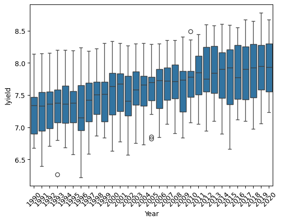

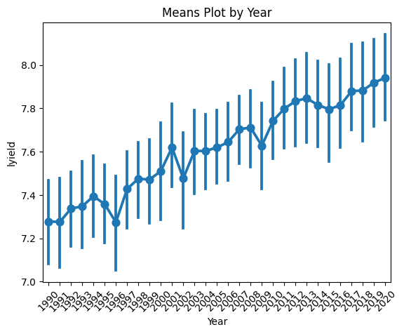

```python
sns.boxplot(agri_p, x='Year', y='lyield')
plt.xticks(rotation=45)
plt.show()


sns.pointplot(agri_p, x='Year', y='lyield')
plt.title('Means Plot by Year')
plt.xticks(rotation=45)
plt.show()
```

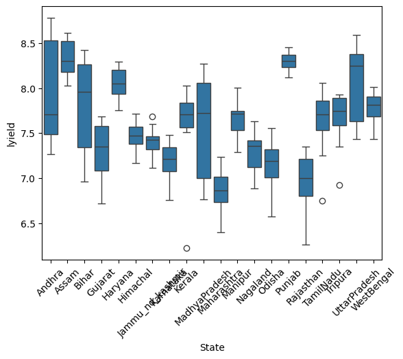

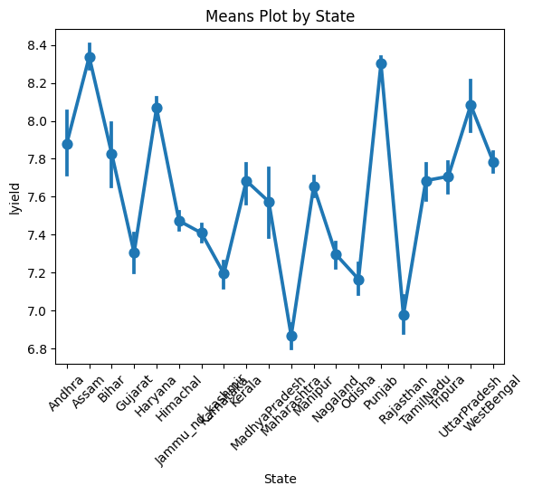

```python
# We can start be exploring heterogeneity across time (year) and individuals (id)
sns.boxplot(agri_p, x='State', y='lyield')
plt.xticks(rotation=45)
plt.show()

# Too many outliers, let's try just plotting the means
sns.pointplot(agri_p, x='State', y='lyield')
plt.title('Means Plot by State')
plt.xticks(rotation=45)
plt.show()
# Cleaner result, easier to interpret
```

As we see difference across time and State in our box plots above, we can conclude that the pooled model is not the right fit. We can explore the effects in the fixed and random effects model

## 2. Fixed Effects

```python
nls_fixedeff = PanelOLS.from_formula(
    'lyield~ 1 + lCo2 + lfertilizer + lrain + lirrigated + lcrop + lcred + lsown + lirr_ratio + ltemp + EntityEffects ', data=agri_p).fit()
print(nls_fixedeff.summary)

# We can now test if we need the fixed effects by performing a
# hypothesis test between the pooled and fixed effects models
print(nls_fixedeff.f_pooled)

# Since p-value ~ 0, we reject H0: no effects needed
# We conclude that fixed effects are needed
```

```
                          PanelOLS Estimation Summary
================================================================================
Dep. Variable:                 lyield   R-squared:                        0.7401
Estimator:                   PanelOLS   R-squared (Between):             -0.1076
No. Observations:                 620   R-squared (Within):               0.7401
Date:                Sat, Dec 07 2024   R-squared (Overall):              0.1735
Time:                        00:01:58   Log-likelihood                    324.75
Cov. Estimator:            Unadjusted
                                        F-statistic:                      186.98
Entities:                          20   P-value                           0.0000
Avg Obs:                       31.000   Distribution:                   F(9,591)
Min Obs:                       31.000
Max Obs:                       31.000   F-statistic (robust):          4.692e+05
                                        P-value                           0.0000
Time periods:                      31   Distribution:                   F(9,591)
Avg Obs:                       20.000
Min Obs:                       20.000
Max Obs:                       20.000

                              Parameter Estimates
===============================================================================
             Parameter  Std. Err.     T-stat    P-value    Lower CI    Upper CI
-------------------------------------------------------------------------------
Intercept   -2.276e+08  1.075e+05    -2118.2     0.0000  -2.278e+08  -2.274e+08
lCo2            0.3945     0.0324     12.189     0.0000      0.3309      0.4580
lfertilizer     0.1203     0.0207     5.8078     0.0000      0.0797      0.1610
lrain           0.1660     0.0377     4.4045     0.0000      0.0920      0.2401
lirrigated  -4.942e+07  2.333e+04    -2118.2     0.0000  -4.947e+07  -4.938e+07
lcrop           0.7095     0.0493     14.381     0.0000      0.6126      0.8064
lcred          -0.0107     0.0031    -3.5001     0.0005     -0.0167     -0.0047
lsown        4.942e+07  2.333e+04     2118.2     0.0000   4.938e+07   4.947e+07
lirr_ratio   4.942e+07  2.333e+04     2118.2     0.0000   4.938e+07   4.947e+07
ltemp          -0.6904     0.7754    -0.8904     0.3736     -2.2133      0.8325
===============================================================================

F-test for Poolability: 119.15
P-value: 0.0000
Distribution: F(19,591)

Included effects: Entity
Pooled F-statistic
H0: Effects are zero
Statistic: 119.1483
P-value: 0.0000
Distributed: F(19,591)
```

# **Understanding the Fixed Effects Model**

### **Intercept:**

- **-2.276e+08 (p-value = 0.0000):**
  - The estimated intercept for the model, though extremely large in magnitude, is statistically significant.

### **Key Variables:**

- **lCo2:**
  - **Coefficient:** 0.3945
  - **p-value:** 0.0000
  - **Interpretation:** An increase in CO2 (*lCo2*) is associated with an increase in yield. The effect is statistically significant.
- **lfertilizer:**
  - **Coefficient:** 0.1203
  - **p-value:** 0.0000
  - **Interpretation:** Higher fertilizer usage increases yield, and the effect is highly significant.
- **lrain:**
  - **Coefficient:** 0.1660
  - **p-value:** 0.0000
  - **Interpretation:** Rainfall has a positive and statistically significant effect on yield.
- **lirrigated:**
  - **Coefficient:** -4.942e+07
  - **p-value:** 0.0000
  - **Interpretation:** Irrigation is associated with a decrease in yield, as indicated by the negative coefficient. The large magnitude suggests potential context dependence or scale issues in the data.
- **lcrop:**
  - **Coefficient:** 0.7095
  - **p-value:** 0.0000
  - **Interpretation:** A greater crop area is strongly and positively associated with yield.
- **lcred:**
  - **Coefficient:** -0.0107
  - **p-value:** 0.0005
  - **Interpretation:** An increase in agricultural credit (*lcred*) is associated with a small decrease in yield, and this effect is statistically significant.
- **lsown:**
  - **Coefficient:** 4.942e+07
  - **p-value:** 0.0000
  - **Interpretation:** A larger area sown is positively associated with yield, and the effect is statistically significant.
- **lirr_ratio:**
  - **Coefficient:** 4.942e+07
  - **p-value:** 0.0000
  - **Interpretation:** The irrigation ratio has a significant and positive effect on yield, similar to the effect of *lsown*.
- **ltemp:**
  - **Coefficient:** -0.6904
  - **p-value:** 0.3736
  - **Interpretation:** Temperature (*ltemp*) has a negative coefficient but is **not statistically significant** as the p-value exceeds the typical threshold of 0.05.

This analysis provides insights into the key factors influencing crop yields and their relative significance based on the model. Furthermore, the f_pooled effects test pvalue is <0.05, establishing that we need to look into the effects plot

## 3. Random Effects

```python
# Random effects model
nls_random = RandomEffects.from_formula(
    'lyield~ 1 + lCo2 + lfertilizer + lrain + lirrigated + lcrop + lcred + lsown + lirr_ratio + ltemp',
    data=agri_p).fit()

print(nls_random.summary)
```

```
                        RandomEffects Estimation Summary
================================================================================
Dep. Variable:                 lyield   R-squared:                        0.7355
Estimator:              RandomEffects   R-squared (Between):              0.3721
No. Observations:                 620   R-squared (Within):               0.7392
Date:                Fri, Dec 06 2024   R-squared (Overall):              0.4938
Time:                        22:58:16   Log-likelihood                    316.30
Cov. Estimator:            Unadjusted
                                        F-statistic:                      188.51
Entities:                          20   P-value                           0.0000
Avg Obs:                       31.000   Distribution:                   F(9,610)
Min Obs:                       31.000
Max Obs:                       31.000   F-statistic (robust):          4.824e+04
                                        P-value                           0.0000
Time periods:                      31   Distribution:                   F(9,610)
Avg Obs:                       20.000
Min Obs:                       20.000
Max Obs:                       20.000

                              Parameter Estimates
===============================================================================
             Parameter  Std. Err.     T-stat    P-value    Lower CI    Upper CI
-------------------------------------------------------------------------------
Intercept   -2.265e+08  1.445e+06    -156.80     0.0000  -2.294e+08  -2.237e+08
lCo2            0.3719     0.0289     12.867     0.0000      0.3151      0.4286
lfertilizer     0.1284     0.0192     6.6960     0.0000      0.0908      0.1661
lrain           0.1820     0.0348     5.2304     0.0000      0.1136      0.2503
lirrigated  -4.919e+07  3.137e+05    -156.80     0.0000  -4.981e+07  -4.858e+07
lcrop           0.6986     0.0470     14.868     0.0000      0.6063      0.7909
lcred          -0.0107     0.0030    -3.5192     0.0005     -0.0167     -0.0047
lsown        4.919e+07  3.137e+05     156.80     0.0000   4.858e+07   4.981e+07
lirr_ratio   4.919e+07  3.137e+05     156.80     0.0000   4.858e+07   4.981e+07
ltemp           0.3081     0.3965     0.7771     0.4374     -0.4705      1.0867
===============================================================================
```

# Understanding the Random Effects Model

This model helps us understand how various factors, such as CO2 emissions, fertilizer use, rainfall, and irrigation, influence crop yields across different states and over time.

### **Key Assumptions**

- The model assumes that unique traits of each state (e.g., geography, soil quality, or policies) are **random** and not directly related to the factors being studied (e.g., CO2, fertilizer).

### **Sources of Information**

The model incorporates insights from:

1. **Changes within each state over time:**
   - For example, increased rainfall in one year compared to the previous year in the same state.
2. **Differences between states:**
   - For example, one state using more fertilizer than another.

## **How is it Different from the Fixed Effects Model?**

### **Random Effects Model:**

- Assumes state-specific traits (e.g., soil type, policies) are **random** and do not directly influence the factors being studied.

### **Fixed Effects Model:**

- Assumes state-specific traits are **unique** and could influence the factors.
  - For example, some states might use more fertilizer due to policy differences or better infrastructure.

## **Why Choose the Random Effects Model?**

- **Key Assumption:**
  - The differences between states (e.g., geography or policies) do not affect factors such as CO2 emissions, fertilizer use, or rainfall.
- **Efficiency:**
  - This model is more efficient because it uses both:
    - State-to-state differences.
    - Changes within each state over time.

```python
# Hausman test for fixed vs random effects model
# H0: random effects model
hausman_psi = nls_fixedeff.cov.iloc[1:,1:] - nls_random.cov.iloc[1:,1:]       # ignore intercept
hausman_diff = nls_fixedeff.params[1:] - nls_random.params[1:]   # ignore intercept

hausman_stat = hausman_diff @ np.linalg.inv(hausman_psi) @ hausman_diff     # compute statistic
hausman_df = nls_random.params.size - 1
hausman_p = chi2.sf(hausman_stat, df=hausman_df)
print('Hausman Test: chisq = {0:.3f}, df = {1}, p-value = {2:.4}'.format(hausman_stat, hausman_df, hausman_p))
```

```
Hausman Test: chisq = -2279.330, df = 9, p-value = 1.0
```

# Model Fit Statistics for Random Effects

### **R-squared (Overall):**

- **0.4938**: Approximately 49.38% of the variation in the dependent variable (*lyield*) is explained by the model, considering both within and between entity variation.

### **R-squared (Within):**

- **0.7392**: Indicates that 73.92% of the variation in *lyield* within entities (e.g., states) over time is explained by the model.

### **R-squared (Between):**

- **0.3721**: About 37.21% of the variation in *lyield* across entities is explained by the model.

### **Log-likelihood:**

- **316.30**: A measure of model fit; higher values indicate a better fit. It can be used to compare similar models for relative performance.

### **F-statistic (and Robust):**

- **188.51 (Robust: 4.824e+04):** The F-test confirms that the overall model is statistically significant, meaning the predictors collectively have a significant influence on *lyield*.

# Parameter Estimates

The coefficients represent the expected percentage change in *lyield* (in log form) for a 1% change in each predictor, holding all other variables constant.

### **Key Variables:**

- **Intercept (-2.265e+08):**
  - The intercept is not meaningful in this log-log model due to its extremely large magnitude, likely caused by scaling issues in the data.
- **lCo2 (0.3719):**
  - A 1% increase in CO2 emissions is associated with an approximate **0.372% increase in yield**, holding other variables constant.
  - This effect is highly significant (**p = 0.0000**).
- **lfertilizer (0.1284):**
  - A 1% increase in fertilizer consumption is associated with an approximate **0.128% increase in yield**, significant at the 0.01 level (**p = 0.0000**).
- **lrain (0.1820):**
  - A 1% increase in annual rainfall corresponds to a **0.182% increase in yield**, significant at the 0.01 level.
- **lcrop (0.6986):**
  - A 1% increase in cropping intensity leads to a **0.699% increase in yield**, indicating strong significance.
- **lcred (-0.0107):**
  - A 1% increase in agricultural credit correlates with a **0.011% decrease in yield**, which may indicate inefficiencies or misallocation of credit resources. This is statistically significant.

This analysis highlights the significant predictors influencing agricultural yield and the overall fit of the random effects model.

```python
data2.describe()
```

|  | Year | Yield_per_hectare | Fertilizer_consp | AnnualRainfall | Gross_irrigated_area | Cropping_intensity | Agri_credit | MaxTemp | Gross_sown_area | CO2_emission | Irrigation_Ratio | Unnamed: 12 | Unnamed: 13 | Unnamed: 14 |
| --- | --- | --- | --- | --- | --- | --- | --- | --- | --- | --- | --- | --- | --- | --- |
| count | 620.000000 | 620.000000 | 620.000000 | 620.000000 | 620.000000 | 620.000000 | 6.200000e+02 | 620.000000 | 620.000000 | 620.000000 | 620.000000 | 0.0 | 0.0 | 1.0 |
| mean | 2005.000000 | 2279.942238 | 106.568177 | 1415.882968 | 3552.667742 | 150.787742 | 1.785492e+02 | 22.599677 | 9595.329032 | 1.133496 | 37.682012 | NaN | NaN | 620.0 |
| std | 8.951494 | 1136.544701 | 81.413580 | 722.812235 | 3079.066305 | 41.496182 | 3.203585e+02 | 7.522449 | 8599.302683 | 0.374422 | 22.763926 | NaN | NaN | NaN |
| min | 1990.000000 | 503.350231 | 0.600000 | 201.510000 | 38.000000 | 100.000000 | 1.000000e-07 | -3.300000 | 187.000000 | 0.647451 | 3.595847 | NaN | NaN | 620.0 |
| 25% | 1997.000000 | 1430.863615 | 47.400000 | 899.930000 | 435.500000 | 121.900000 | 8.277500e+00 | 23.700000 | 2225.750000 | 0.817360 | 20.877002 | NaN | NaN | 620.0 |
| 50% | 2005.000000 | 1968.481335 | 85.700000 | 1197.275000 | 3509.000000 | 139.300000 | 3.080000e+01 | 25.315000 | 7864.500000 | 0.984261 | 31.451964 | NaN | NaN | 620.0 |
| 75% | 2013.000000 | 2825.427005 | 150.450000 | 1845.655000 | 5674.000000 | 170.525000 | 1.887500e+02 | 26.070000 | 12878.000000 | 1.527674 | 48.296870 | NaN | NaN | 620.0 |
| max | 2020.000000 | 6505.000000 | 494.600000 | 3718.890000 | 18424.000000 | 312.900000 | 1.980530e+03 | 28.230000 | 35615.000000 | 1.795595 | 99.055742 | NaN | NaN | 620.0 |